# Identier les facteurs latents en SHS avec R

```r
resid(fact_2immo,type="standardized")
```

```
$type
[1] "standardized"

$cov
                                 prx_md prc_l_ md_nv_ prc_ms prc_t_ dns_pp
prix_med                          0.000
perc_log_vac                      0.012  0.000
med_niveau_vis                    0.348 -3.556  0.000
perc_maison                      -1.848 -0.228  1.073  0.000
perc_tiny_log                    -8.424  6.333 -2.252 -3.356  0.000
dens_pop                         -0.541  2.049 -0.318  4.454  1.377  0.000
part_agri_nb_emploi              -4.774  4.943 -5.347  2.048  2.553  4.785
part_cadre_profintellec_nbemploi  1.741  0.320  4.251  9.082  0.042  2.270
                                 prt_g__ prt_c__
prix_med
perc_log_vac
med_niveau_vis
perc_maison
perc_tiny_log
dens_pop
part_agri_nb_emploi                0.000
part_cadre_profintellec_nbemploi  -2.261   0.000
```

**Etape 4 : Représenter les deux modèles :**

Voici donc la représentation des équations structurelles, représentations qui obéit à un certain nombre de codes visuels : les rectangles renvoient aux variables observées, les ellipses aux variables latentes, les doubles flèches associées aux rectangles et aux ellipses à l’erreur de chaque variable. Les couleurs vertes et rouges renvoient au signe de la corrélation et l’épaisseur à la force de la corrélation entre les variables et les facteurs.

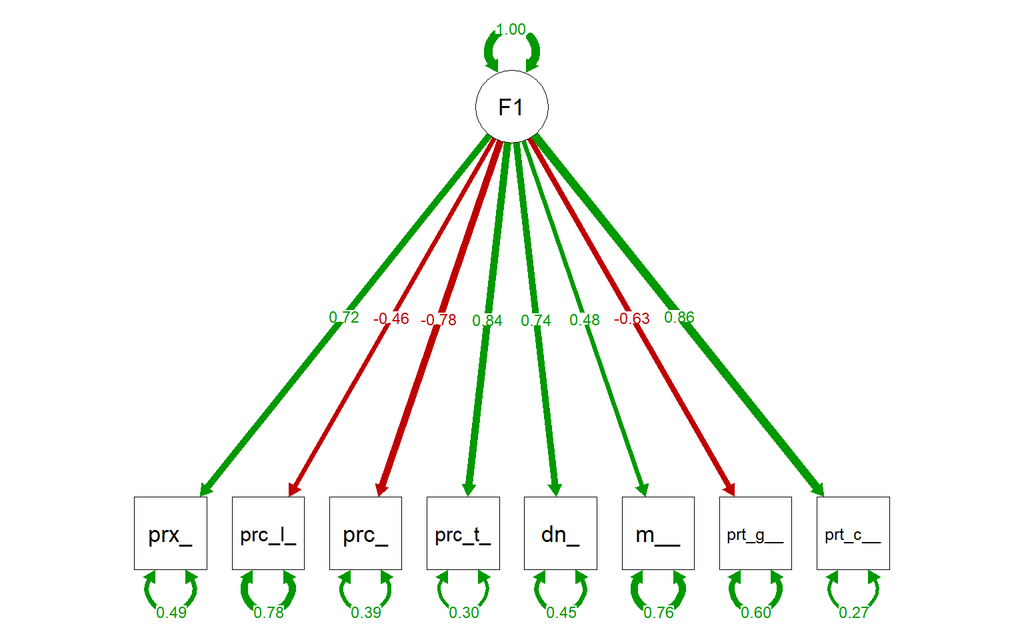

```r
semPlot::semPaths(fact_1immo, "std",
             sizeMan = 8, sizeInt = 8, sizeLat = 8,
             edge.label.cex=0.8,
             fade=FALSE)
```

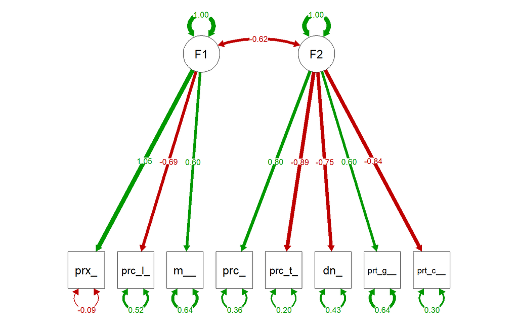

```r
semPlot::semPaths(fact_2immo, "std",
             sizeMan = 8, sizeInt = 8, sizeLat = 8,
             edge.label.cex=0.8,
             fade=FALSE)
```

**Etape 5 : Comparer nos deux modèles**

Tout notre enjeu ici va être de comparer les deux modèles et de choisir celui qui s’ajuste le mieux à nos données. Pour ce faire nous pouvons comparer les deux modèles sur différents indices.

```r
# Pour comparer les modèles à l'aide des indices tel que l'AIC, le RMSEA, R2...
performance::compare_performance(fact_1immo, fact_2immo, verbose = FALSE)
```

```
# Comparison of Model Performance Indices

Name       |  Model |    Chi2 | Chi2_df | p (Chi2) | Baseline(28) | p (Baseline) |   GFI |  AGFI |   NFI |  NNFI |   CFI | RMSEA |    RMSEA  CI | p (RMSEA) |   RMR |  SRMR |   RFI |  PNFI |   IFI |   RNI | Loglikelihood |   AIC (weights) |   BIC (weights) | BIC_adjusted
------------------------------------------------------------------------------------------------------------------------------------------------------------------------------------------------------------------------------------------------------------------------------
fact_1immo | lavaan | 942.906 |  20.000 |   < .001 |     3130.441 |       < .001 | 0.713 | 0.483 | 0.699 | 0.584 | 0.703 | 0.275 | [0.26, 0.29] |    < .001 | 0.111 | 0.117 | 0.578 | 0.499 | 0.703 | 0.703 |     -5753.474 | 11538.9 (<.001) | 11609.6 (<.001) |    11558.793
fact_2immo | lavaan | 405.704 |  19.000 |   < .001 |     3130.441 |       < .001 | 0.860 | 0.734 | 0.870 | 0.816 | 0.875 | 0.183 | [0.17, 0.20] |    < .001 | 0.072 | 0.072 | 0.809 | 0.591 | 0.876 | 0.875 |     -5484.873 | 11003.7 (>.999) | 11078.8 (>.999) |    11024.831
```

```r
# Une autre manière de visualiser très utile.
effectsize::interpret(fact_1immo)
```

```
    Name     Value Threshold Interpretation
1    GFI 0.7128007      0.95           poor
2   AGFI 0.4830413      0.90           poor
3    NFI 0.6987947      0.90           poor
4   NNFI 0.5835319      0.90           poor
5    CFI 0.7025228      0.90           poor
6  RMSEA 0.2748166      0.05           poor
7   SRMR 0.1167064      0.08           poor
8    RFI 0.5783126      0.90           poor
9   PNFI 0.4991391      0.50           poor
10   IFI 0.7032879      0.90           poor
```

```r
effectsize::interpret(fact_2immo)
```

```
    Name      Value Threshold Interpretation
1    GFI 0.85952648      0.95           poor
2   AGFI 0.73383964      0.90           poor
3    NFI 0.87040035      0.90           poor
4   NNFI 0.81631249      0.90           poor
5    CFI 0.87535490      0.90           poor
6  RMSEA 0.18251224      0.05           poor
7   SRMR 0.07226651      0.08   satisfactory
8    RFI 0.80901104      0.90           poor
9   PNFI 0.59062881      0.50   satisfactory
10   IFI 0.87571544      0.90           poor
```

Concrètement, le deuxième modèle testé, avec 2 facteurs latents permettrait de mieux rendre compte de la complexité de nos données. Celui-ci s’ajustant le mieux à nos données.

La fonction `interpret()` donne des résultats pour 10 indices d’ajustement du modèle testé aux données de l’échantillon présenté. Toutefois, ces différents indices ont été proposé au fur et à mesure du développement des modèles en équations structurelles et, s’ils ne testent pas exactement la même chose, ils permettent de rendre compte de l’ajustement d’un modèle aux données présentées. Il n’est pas nécessaire que l’ensemble des indices présentés soient satisfaisant pour envisager un bon ajustement. Dans la littérature, certains indices sont sélectionnés et tous ne sont pas présentés. De plus, une utilisation trop contrainte des seuils augmente la probabilité de faux négatifs, c’est-à-dire de considérer qu’un modèle ne s’ajusterait pas aux données alors que si (Hooper et al., 2008). Prenons l’exemple d’un indice très cité et présenté dans la littérature tel que le CFI **Comparative Fit Indice**. Que fait-il exactement ? Il compare le modèle d’intérêt avec un modèle restreint qui sert de base. Itération de modèles entre le pire (modèle nul – à 0) et le parfait (voir modèle saturé - 1) et le CFI indique où se situe le modèle d’intérêt (le notre) sur ce continuum. Le seuil communément accepté de .95 indique une réduction de l’erreur, par rapport au modèle nul, de 95%. Le modèle nul étant un modèle où toutes les relations entre les variables sont rapportées à 0. Donc en gros notre modèle s’ajuste à nos données avec un risque de 5% que ce soit du au hasard. Quel que soit le contexte on est satisfait d’avoir une réduction de l’erreur de 95%. Donc plus le seuil est inférieur à .95, plus le risque que l’ajustement soit du au hasard augmente. (Van Laar, S., & Braeken, J., 2021).

Le package Lavaan, fait également quelques propositions pour améliorer notre modèle. Théoriquement, en tenant compte de toutes ces propositions, le modèle s’ajusterait parfaitment, mais on serait dans un cas évident de sur-ajustement aux données. En revanche, cela peut être intéressant d’en prendre connaissance afin de vérifier qu’aucune relation n’ait été oubliée et qui permettrait d’améliorer significativement le modèle. Cette relation doit bien évidemment faire sens théoriquement. La syntaxe utilisée est celle du package lavaan, on peut en trouver une traduction [ici](https://lavaan.ugent.be/tutorial/syntax1.html)

```r
modindices(fact_1immo) %>% arrange(-mi) %>% head(20)
```

```
              lhs op                              rhs      mi    epc sepc.lv
1        prix_med ~~                     perc_log_vac 280.362 -0.424  -0.424
2        prix_med ~~                   med_niveau_vis 163.690  0.310   0.310
3    perc_log_vac ~~                    perc_tiny_log 128.739  0.265   0.265
4     perc_maison ~~                    perc_tiny_log 109.857 -0.205  -0.205
5        prix_med ~~                    perc_tiny_log 104.438 -0.191  -0.191
6   perc_tiny_log ~~                   med_niveau_vis 101.191 -0.225  -0.225
7    perc_log_vac ~~                   med_niveau_vis  73.572 -0.273  -0.273
8     perc_maison ~~ part_cadre_profintellec_nbemploi  71.433  0.176   0.176
9        dens_pop ~~              part_agri_nb_emploi  42.739  0.132   0.132
10    perc_maison ~~                   med_niveau_vis  38.965  0.154   0.154
11  perc_tiny_log ~~                         dens_pop  37.038  0.098   0.098
12       dens_pop ~~ part_cadre_profintellec_nbemploi  30.192  0.093   0.093
13   perc_log_vac ~~              part_agri_nb_emploi  22.275  0.146   0.146
14  perc_tiny_log ~~ part_cadre_profintellec_nbemploi  18.964  0.088   0.088
```

[output cut: 27 more lines]

```r
modindices(fact_2immo) %>% arrange(-mi) %>% head(20)
```

```
                   lhs op                              rhs     mi    epc
1       med_niveau_vis ~~ part_cadre_profintellec_nbemploi 78.668  0.180
2          perc_maison ~~ part_cadre_profintellec_nbemploi 78.422  0.184
3                   F1 =~                    perc_tiny_log 72.999 -0.260
4             prix_med ~~                      perc_maison 57.630 -0.101
5          perc_maison ~~                    perc_tiny_log 43.773 -0.129
6       med_niveau_vis ~~                      perc_maison 42.017  0.131
7                   F1 =~                      perc_maison 39.469 -0.212
8         perc_log_vac ~~              part_agri_nb_emploi 34.205  0.141
9             dens_pop ~~              part_agri_nb_emploi 32.074  0.115
10            dens_pop ~~ part_cadre_profintellec_nbemploi 29.715  0.093
11        perc_log_vac ~~                    perc_tiny_log 25.936  0.081
12         perc_maison ~~                         dens_pop 21.207  0.076
13                  F2 =~                     perc_log_vac 15.540 -0.195
14            prix_med ~~                   med_niveau_vis 15.539 -0.160
```

[output cut: 27 more lines]

## 6.2 2ème exemple : étudier la variation dans le temps d’un modèle

Un usage pertinent du couple AFE/AFC peut être d’étudier la permanence d’un phénomène. Ainsi, on peut utiliser l’AFE dans un premier temps pour faire émerger un modèle et vérifier dans un second temps avec l’analyse factorielle confirmatoire si le modèle est resté le même.

Dans cet article, nous venons de mettre en pratique le couple AFE/AFC dans le cadre d’une première approche afin de sélectionner le meilleur modèle factoriel. Voyons à présent si un modèle produit à l’aide d’une AFE, sur des données de 2011, se confirme sur des données de 2023. Ceci nous permettra de mettre en évidence ou non la permanence des phénomènes en présence.

Nous utiliserons des données issue de l’INED dans un premier temps sur le cru 2011

- PAYS : Les différents pays du monde
- Superf : Superficie des différents pays en km²
- Pop : Nombre d’habitants en 2011
- tx_natalite : Le taux de natalité est le rapport du nombre de naissances vivantes de l’année à la population totale moyenne de l’année
- tx_mortalite : Le taux de mortalité est le rapport du nombre de décès de l’année à la population totale moyenne de l’année
- pop2050 : Projection du nombre d’habitants en 2050
- tx_mort_infantile : Nombre de décès d’enfants de moins d’un an rapporté au nombre de naissances vivantes
- indice_fecond : Le nombre d’enfants nés vivants des femmes d’un âge donné (ou d’une tranche d’âge) au cours de l’année, rapporté à la population moyenne de l’année des femmes de même âge (ou de la même classe d’âge) indique le taux de fécondité. L’indice de fécondité est la somme des taux de fécondité par âge d’une année.
- moins15 : Le nombre d’habitants de moins de 15 ans
- plus65 : Le nombre d’habitants de plus de 65 ans
- espvie_homme : Age moyen de décès atteint par les hommes en 2011
- espvie_femme : Age moyen de décès atteint par les femmes en 2011
- RNB_hab : Revenu National Brut rapporté au nombre d’habitants

### 6.2.1 Préparation des données

```r
library(here)
csv_path <- here("data", "pop_societe_2011.csv")

pop2011 <- read.csv2(csv_path, row.names=1)

### Centrer et réduire les variables
dfz_2011 <-  data.frame(scale(pop2011, center=T, scale=T))
```

Nous ne présenterons pas les statistiques descriptives dans cet exemple afin de ne pas allourdir la lecture de cet article, toutefois, elles ont bien été vérifiées par les auteurs.

Vérification des outliers et de la multicolinéarité : Nous faisons le choix ici d’être plus stricte concernant les outliers et les variables multicolinéaires. Cela comme précédemment, doit être assumé et justifié lors de l’analyse.

### 6.2.2 Nettoyage des données

Etape 1 : les outliers

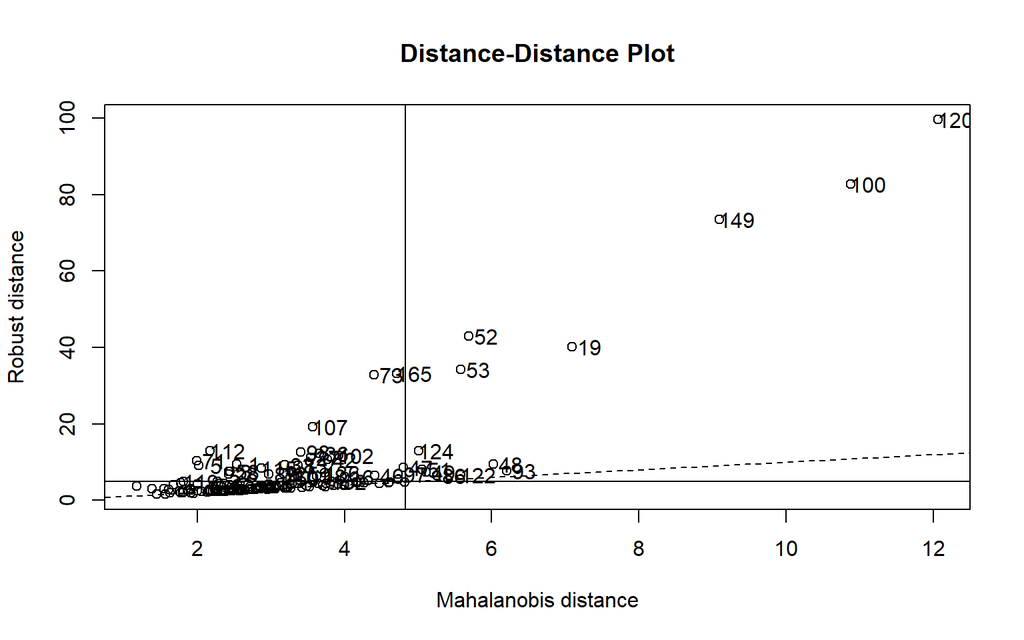

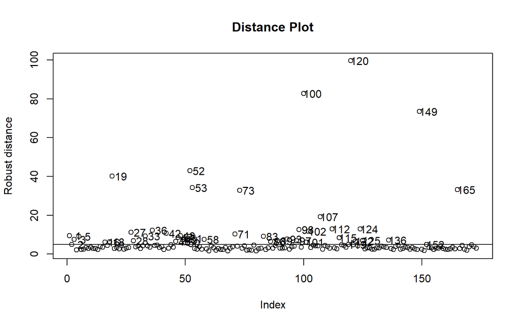

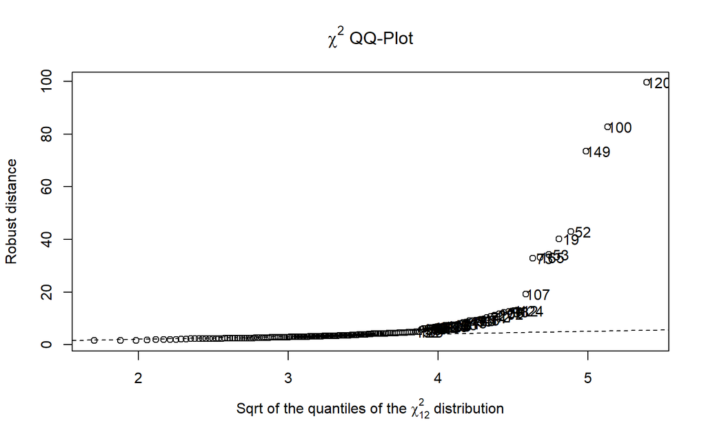

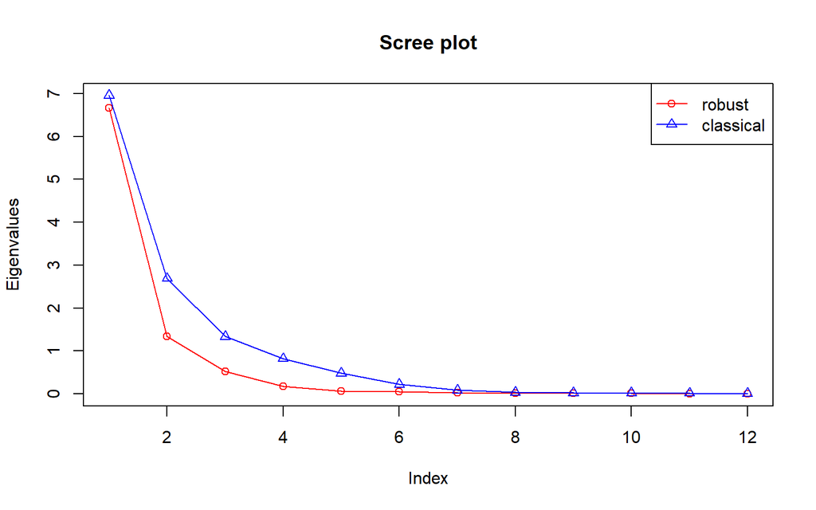

```r
# Multioutliers
#MCD avec le package rrcov
library(rrcov)
# 1- calcul de la distance MCD
mcd_result_2011 <- CovMcd(dfz_2011, alpha=0.75)

# 2- visualisation des outliers
plot(mcd_result_2011, which="all")
```

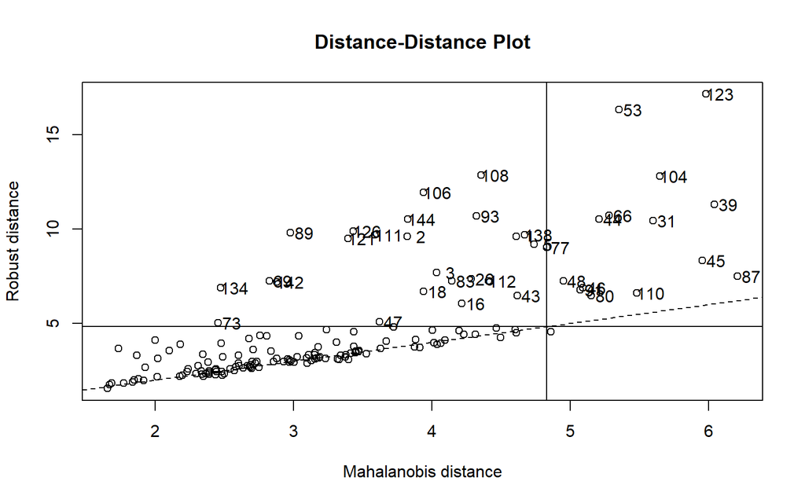

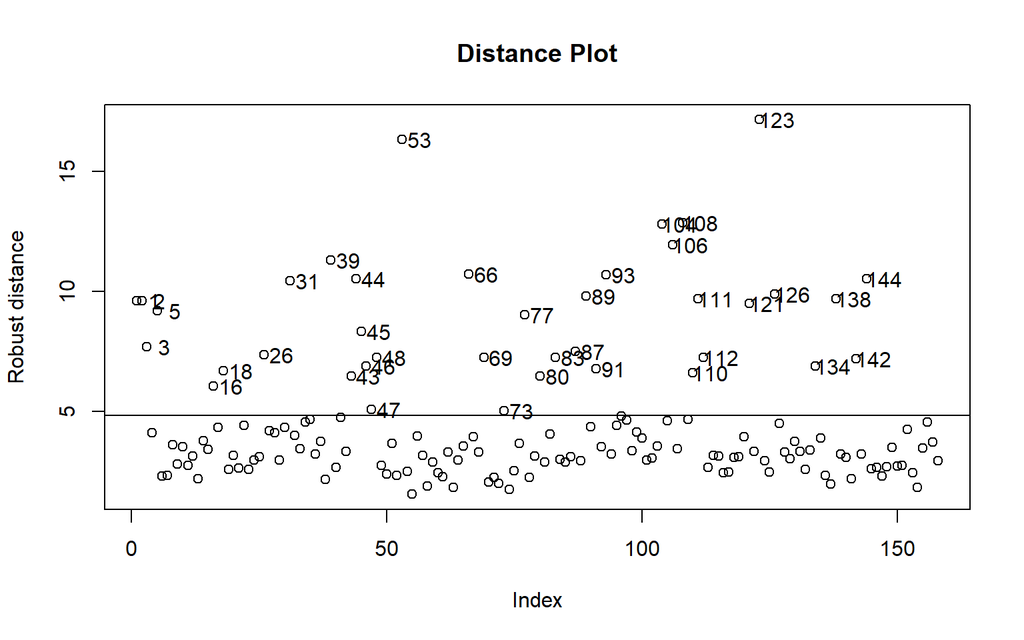

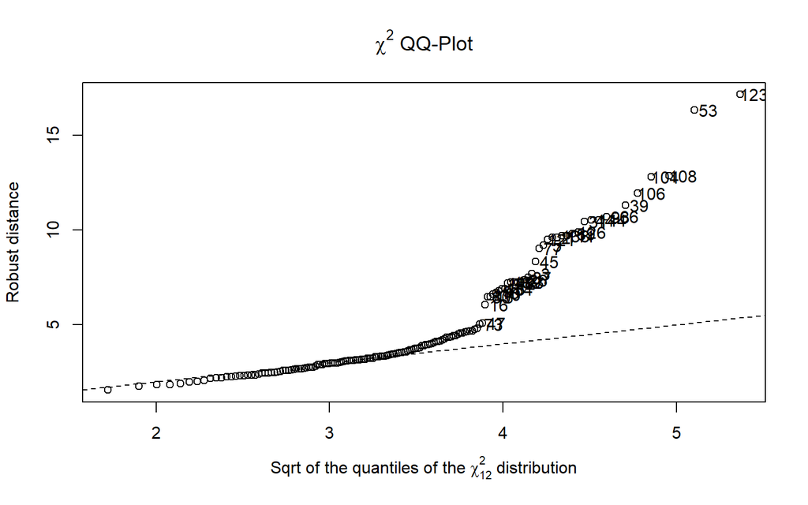

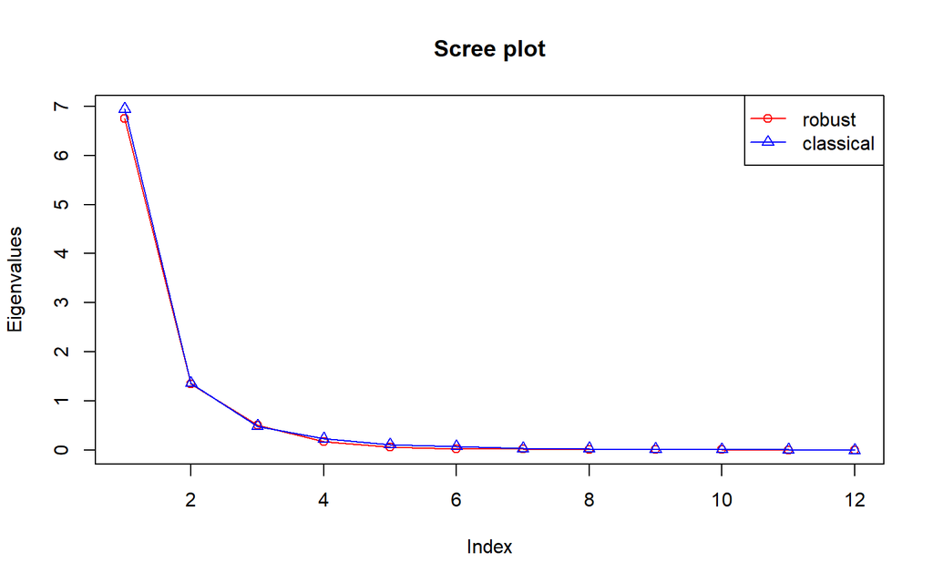

```r
# suppression des valeurs manquantes
dfz_2011out<-cbind(dfz_2011, mcd_result_2011$wt)
dfz_2011outp<-subset(dfz_2011out, mcd_result_2011$wt %in% c(0,1))

# fusion de la base initiale et des distances de mahalanobis robustes
dfz_2011mah<-cbind(dfz_2011outp, mcd_result_2011$raw.mah)

# 3- suppression des outliers
dfz_2011p<-subset(dfz_2011mah, dfz_2011mah$`mcd_result_2011$raw.mah`< 100)

# On recalcule la distance de mahalanobis robuste sur notre base de données sans les premiers outliers, pour voir s'il en reste
dfz_2011_B<-subset(dfz_2011p, select = -c(`mcd_result_2011$raw.mah`, `mcd_result_2011$wt`))
# 1- calcul de la distance MCD
mcd_result_2011_2 <- CovMcd(dfz_2011_B, alpha=0.75)
# L'objet `mcd_result` contient toutes les informations concernant le calcul sur notre base de données
# 2- visualisation des outliers
plot(mcd_result_2011_2, which="all")
```

15 outliers ont été supprimé avec le calcul de la distance de mahalanobis robuste. La suppression des outliers a été réalisée suite au calcul de la distance de mahalanobis robuste où le seuil de 100 comprend les valeurs les plus éloignées. L’objectif est de sortir de l’analyse les individus statistiques les plus porteurs de biais, néanmoins pour conserver du sens dans notre base de données nous ne supprimons pas tous les outliers relevé par la fonction, d’où le choix du seuil de 100. Ce seuil a été déterminé suite à différentes itérations sur notre jeux de données. Il sera donc différent avec d’autres données.

A présent aucune observation ne semble se détacher fortement des autres. Notre base de données compte maintenant 158 pays (sans la Chine, l’Inde, les Etats-Unis, le Canada, l’Australie, la Russie et bien d’autres…).

Etape 2 : la multicolinéarité

```r
# corrélations

cor <- correlation(dfz_2011_B, method = "spearman")

cor %>%
  summary(redundant = FALSE)
```

```
# Correlation Matrix (spearman-method)

Parameter         |  RNB_hab | espvie_femme | espvie_homme |   plus65 | moins15 | indice_fecond | tx_mort_infantile | pop2050 | tx_mortalite | tx_natalite |     Pop
--------------------------------------------------------------------------------------------------------------------------------------------------------------------
Superf            |    -0.20 |       -0.25* |        -0.24 |    -0.20 |    0.24 |         0.27* |             0.27* | 0.77*** |         0.14 |       0.27* | 0.74***
Pop               |    -0.09 |        -0.04 |        -0.05 |    -0.02 |    0.07 |          0.07 |              0.07 | 0.98*** |         0.09 |        0.07 |
tx_natalite       | -0.83*** |     -0.86*** |     -0.77*** | -0.92*** | 0.97*** |       0.98*** |           0.89*** |   0.25* |         0.13 |             |
tx_mortalite      |    -0.22 |     -0.38*** |     -0.51*** | 6.83e-03 |    0.10 |          0.16 |             0.27* |    0.12 |              |             |
pop2050           |    -0.23 |        -0.18 |        -0.18 |    -0.19 |    0.24 |         0.25* |              0.23 |         |              |             |
tx_mort_infantile | -0.87*** |     -0.94*** |     -0.89*** | -0.85*** | 0.90*** |       0.86*** |                   |         |              |             |
indice_fecond     | -0.80*** |     -0.83*** |     -0.74*** | -0.89*** | 0.96*** |               |                   |         |              |             |
moins15           | -0.84*** |     -0.84*** |     -0.76*** | -0.91*** |         |               |                   |         |              |             |
plus65            |  0.77*** |      0.84*** |      0.74*** |          |         |               |                   |         |              |             |
espvie_homme      |  0.82*** |      0.94*** |              |          |         |               |                   |         |              |             |
espvie_femme      |  0.85*** |              |              |          |         |               |                   |         |              |             |

p-value adjustment method: Holm (1979)
```

```r
### Etude du VIF

vifstep(dfz_2011_B, method = "spearman")
```

```
5 variables from the 12 input variables have collinearity problem:

tx_natalite espvie_homme espvie_femme moins15 pop2050

After excluding the collinear variables, the linear correlation coefficients ranges between:
min correlation ( plus65 ~ tx_mortalite ):  0.006826529
max correlation ( plus65 ~ indice_fecond ):  -0.8874719

---------- VIFs of the remained variables --------
          Variables      VIF
1            Superf 1.502763
2               Pop 1.423677
3      tx_mortalite 4.108345
4 tx_mort_infantile 8.688467
5     indice_fecond 4.762499
6            plus65 6.947084
7           RNB_hab 2.292747
```

```r
dfz2011_multi <- dfz_2011_B %>% select(-tx_natalite, -espvie_homme, -pop2050, -moins15, -tx_mortalite, -espvie_femme )
vifstep(dfz2011_multi, method = "spearman")
```

```
No variable from the 6 input variables has collinearity problem.

The linear correlation coefficients ranges between:
min correlation ( plus65 ~ Pop ):  -0.0172211
max correlation ( plus65 ~ indice_fecond ):  -0.8874719

---------- VIFs of the remained variables --------
          Variables      VIF
1            Superf 1.500557
2               Pop 1.405872
3 tx_mort_infantile 4.279781
4     indice_fecond 4.749530
5            plus65 2.757888
6           RNB_hab 2.078991
```

```r
# Après suppression des variables colinéaires, notre jeu de données en compte 6.
```

### 6.2.3 Réaliser l’AFE sur les données 2011

Etape 1 : Déterminer le nombre de facteurs

```r
# Regardons à présent en combien de facteurs latents se structurent nos variables
n <- n_factors(dfz2011_multi)
n
```

```
# Method Agreement Procedure:

The choice of 2 dimensions is supported by 8 (50.00%) methods out of 16 (Optimal coordinates, Acceleration factor, Parallel analysis, Kaiser criterion, Scree (SE), VSS complexity 1, BIC, BIC (adjusted)).
```

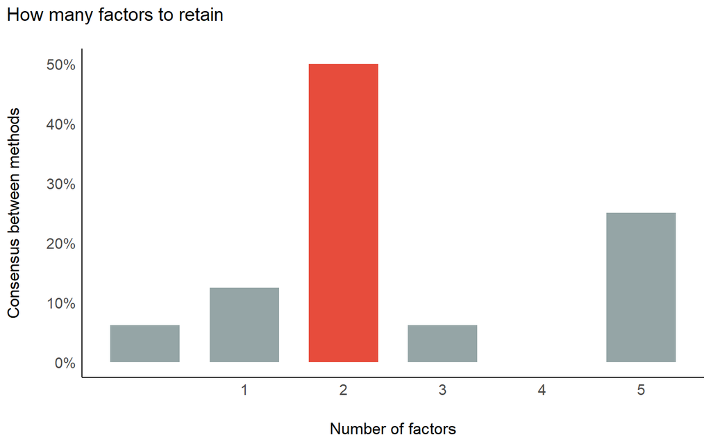

```r
library(see)
plot(n) + theme_modern()
```

```r
# Les méthodes suggèrent 2 facteurs
```

Etape 2 : Vérifier le KMO et la sphéracité

```r
performance::check_factorstructure(dfz2011_multi)
```

```
# Is the data suitable for Factor Analysis?


  - Sphericity: Bartlett's test of sphericity suggests that there is sufficient significant correlation in the data for factor analysis (Chisq(15) = 504.50, p < .001).
  - KMO: The Kaiser, Meyer, Olkin (KMO) overall measure of sampling adequacy suggests that data seems appropriate for factor analysis (KMO = 0.72). The individual KMO scores are: Superf (0.56), Pop (0.45*), tx_mort_infantile (0.73), indice_fecond (0.72), plus65 (0.80), RNB_hab (0.82).
```

```r
# Nos données sont factorisables
```

Etape 3 : Réaliser l’AFE

```r
# efa
efa_2011 <- lavaan::efa(dfz2011_multi, nfactors = 2, rotation="promax", estimator="MLR")
efa_2011
```

```
                      f1     f2
Superf             0.988
Pop                0.533      .
tx_mort_infantile         0.903
indice_fecond             0.945
plus65                   -0.759
RNB_hab                  -0.668
```

Nous avons donc deux facteurs latents. Un premier qui corrèle positivement avec la surface et la population, et un deuxième facteur latent qui oppose d’un côté score élevé sur la mortalité infantile et indice de fécondité avec de l’autre la proportion d’habitant de plus de 65 ans et et le revenu national brut par habitant.

### 6.2.4 2ème temps L’analyse factorielle confirmatoire

Testons si la structure factorielle obtenue grâce à l’AFE se retrouve sur les données de 2023. Si c’est le cas cela implique une permanence en 2023 du phénomène étudié en 2011.

Etape 1 : Chargement et préparation des données

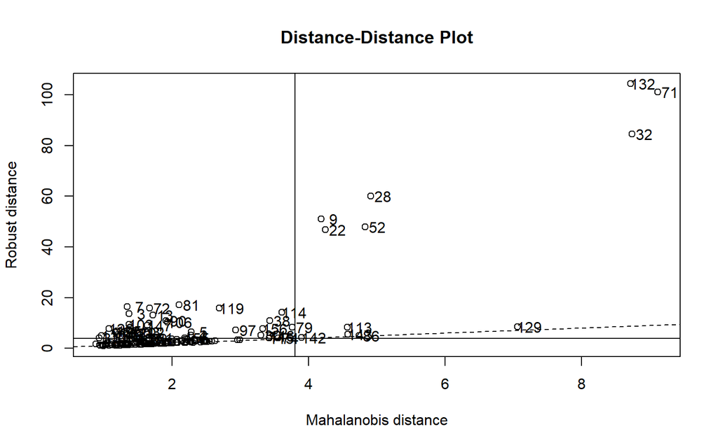

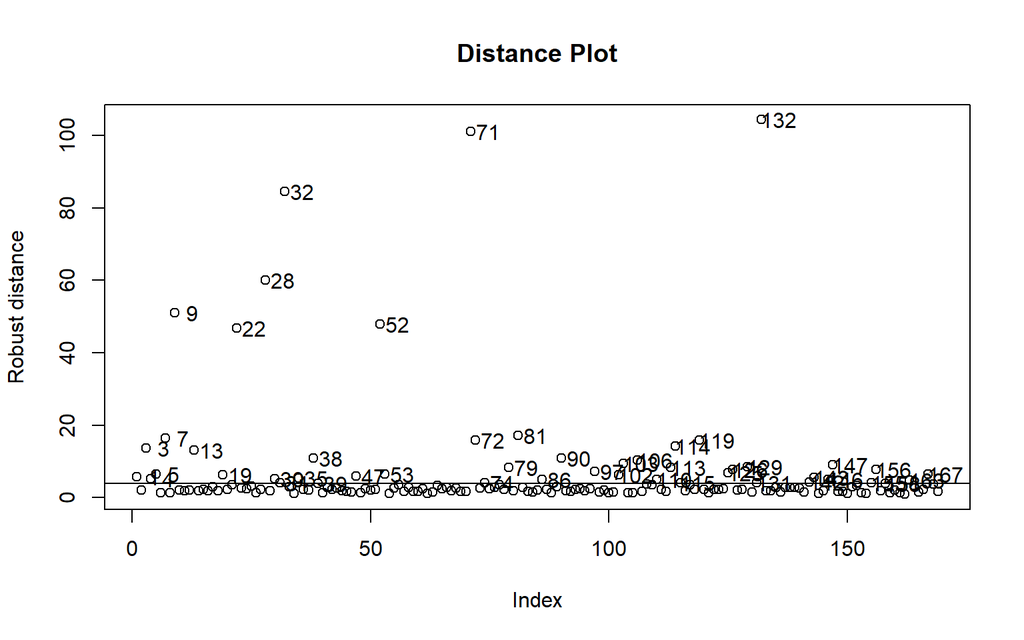

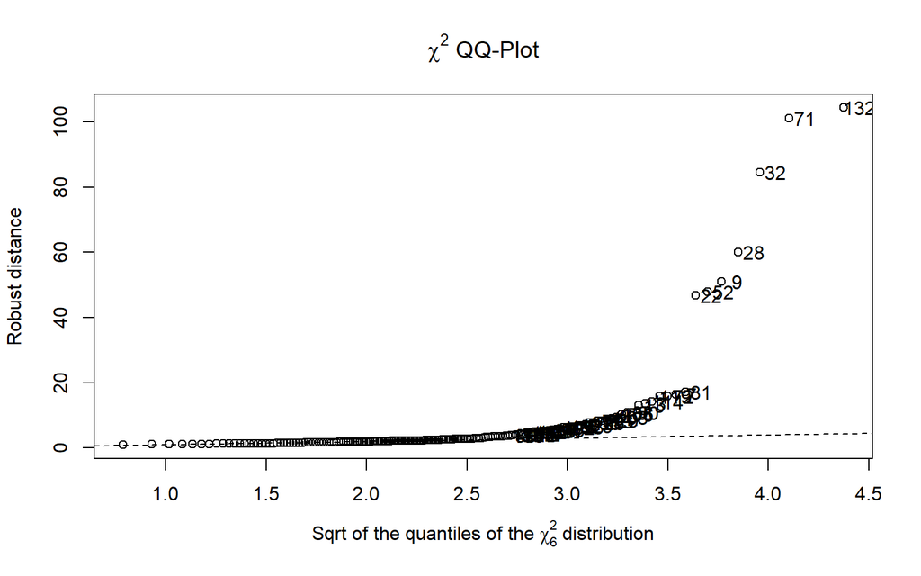

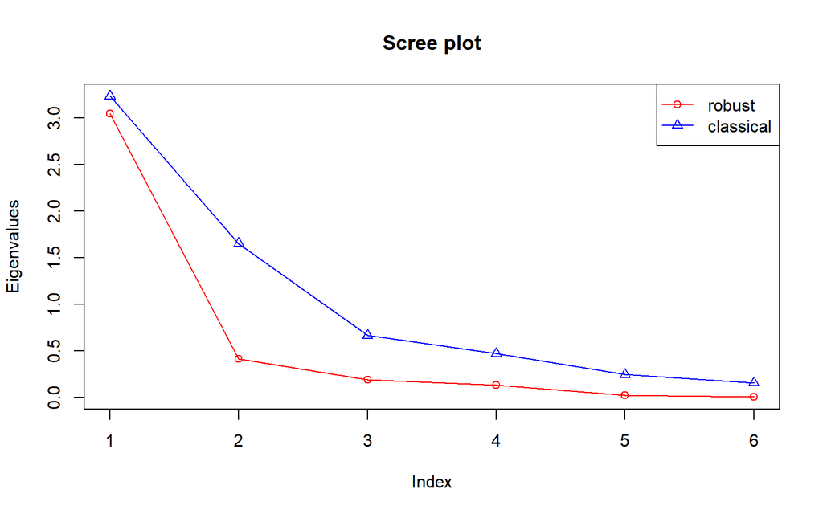

```r
# Charger les données

library(here)
csv_path <- here("data", "data_monde_afe_02.csv")

pop2023 <- read.csv2(csv_path, row.names=1)

pop2023p<-subset(pop2023, select = c(Superf, Pop, tx_mort_infantile, indice_fecond, RNB_hab, plus65))

### Centrer et réduire les variables
dfz_2023 <-  data.frame(scale(pop2023p, center=T, scale=T))


# Multioutliers
# MCD avec le package rrcov
library(rrcov)
# 1- calcul de la distance MCD
mcd_result_2023 <- CovMcd(dfz_2023, alpha=0.75)
# L'objet `mcd_result` contient toutes les informations concernant le calcul sur notre base de données
# 2- visualisation des outliers
plot(mcd_result_2023, which="all")
```